# Prosper Loans - Loan Amounts, Interest Rates & Geography

## by Ernest Rowe

## Investigation Overview

In this report, I examined the effects that borrower characteristics had on loan amounts & interests rates. I also looked at the geographic distribution of loans and tracked how Prosper's lending footprint changed over time.

## Dataset Overview

The dataset originally contained 113,937 loans with 81 variables, including loan amount, borrower interest rate, current loan status, borrower income, and many others. After removing duplicate records and doing some feature engineering, 113,066 records remained with 85 variables. More information on the variables in this dataset can be found [here](https://www.google.com/url?q=https://docs.google.com/spreadsheet/ccc?key%3D0AllIqIyvWZdadDd5NTlqZ1pBMHlsUjdrOTZHaVBuSlE%26usp%3Dsharing&sa=D&ust=1546576456544000). Population data from [census.gov](https://www2.census.gov/programs-surveys/popest/datasets/2010-2018/national/totals/nst-est2018-alldata.csv) was also used in this analysis.

## Loan Amount & Interest Rate vs Credit Score

In the first scatter plot of this section, a log transformation was performed on loan amount. In doing this, the correlation coefficient $\rho$ went from 0.34 to 0.38, improving the linear relationship between loan amount & credit score. The 2nd plot, for interest rate & credit score, did not undergo a transformation and had a stronger, yet negative relationship. The $\rho$ for this plot was -0.46.

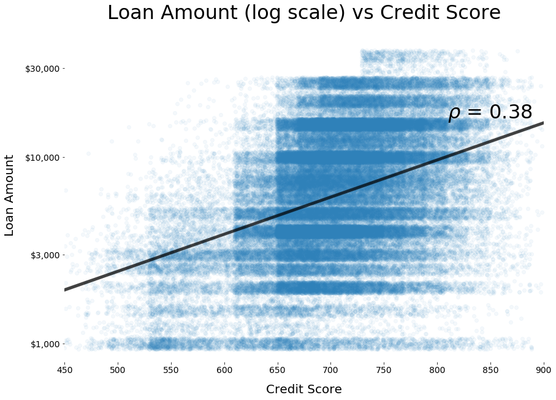

```python
plt.figure(figsize=[14,10])

ax = sns.regplot(data=df, x='CreditScoreRangeUpper', y='LogLoanOriginalAmount', x_jitter=10, y_jitter=0.03,
                 scatter_kws={'alpha':0.05}, line_kws={'color':'k','alpha':0.7,'lw':5})

y_labels = [1000, 3000, 10000, 30000]

plt.title('Loan Amount (log scale) vs Credit Score', fontdict={'fontsize':32}, pad=15)
plt.xlabel('Credit Score', fontdict={'fontsize':20}, labelpad=15)
plt.ylabel('Loan Amount', fontdict={'fontsize':20}, labelpad=15)

plt.yticks(np.log10(y_labels), ['${:,.2f}'.format(x)[:-3] for x in y_labels])
plt.tick_params(labelsize=14)

plt.xlim(450, 900)
plt.ylim(np.log10(800))

plt.box(on=False)
corr(df, 'CreditScoreRangeUpper', 'LogLoanOriginalAmount', xy=(0.8, 0.73));
```

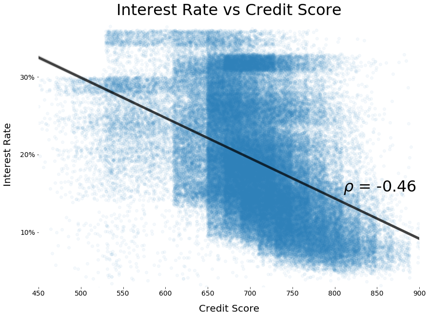

```python
plt.figure(figsize=[14,10])

ax = sns.regplot(data=df, x='CreditScoreRangeUpper', y='BorrowerRate', x_jitter=10, y_jitter=0.01,
                 scatter_kws={'alpha':0.05}, line_kws={'color':'k','alpha':0.7,'lw':5})

plt.title('Interest Rate vs Credit Score', fontdict={'fontsize':32}, pad=15)
plt.xlabel('Credit Score', fontdict={'fontsize':20}, labelpad=15)
plt.ylabel('Interest Rate', fontdict={'fontsize':20}, labelpad=15)

locs, labels = plt.yticks()
plt.yticks(locs, ['{:.0%}'.format(x) for x in locs])
plt.tick_params(labelsize=14)

plt.xlim(450, 900)
plt.ylim(0.03, 0.37)

plt.box(on=False)
corr(df, 'CreditScoreRangeUpper', 'BorrowerRate', xy=(0.8, 0.36));
```

## Loan Amount & Interest Rate vs Categorical Features

In the following two slides, the distributions of loan amount (log scale) & interest rate are plotted against categorical variables. The first set of violin plots groups the two features of interest by loan `Term` and the second set of plots groups by `OriginationYear`.

In the first slide, we see that loan amount & interest rate both increase as the loan `Term` increases. Borrowers with a 1 Year loan enjoy lower interest rates, but they also have much higher loan payments. Their maximum loan amount is also capped at $\$$25,000, whereas 3 & 5 year terms both go as high as $\$$35,000. Paying attention to the interquartile ranges, you'll see that almost all of the people taking out 5 year loans do so for large loan amounts.

In the slide with plots for `OriginationYear`, you can see that loan amounts were on the rise up until 2008 & 2009 when the market took a tumble. They bounced back relatively quickly and had surpassed pre-recession loan amounts by 2011 when the minimum loan amount was raised from $\$$1,000 to $\$$2,000. The trend continued in 2013 & 2014 where the maximum loan amount was raised from $\$$25,000 to $\$$35,000 and an even smaller proportion of loans had low loan amounts.

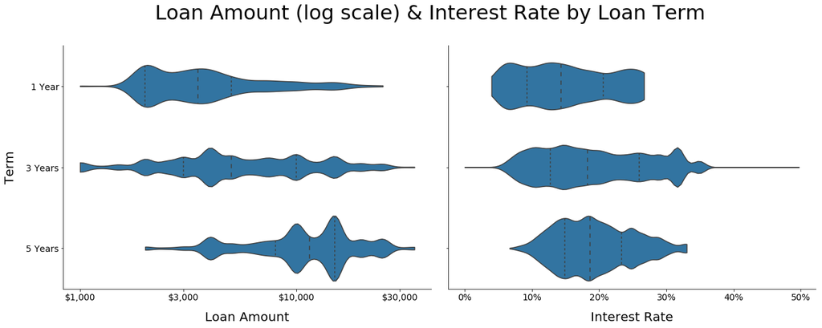

```python
# Create a PairGrid plotting LoanOriginalAmount & LogLoanOriginalAmount against categoric_vars.
x_labels = [0, 1000, 3000, 10000, 30000]

g = sns.PairGrid(data=df,  x_vars=['LogLoanOriginalAmount', 'BorrowerRate'], y_vars=['Term'],
                 height=7, aspect=1.25)

g.axes[-1,0].set_xticks(np.log10(x_labels))

g.map(sns.violinplot, inner='quartile', cut=0)

g.axes[-1,0].set_ylabel('Term', fontdict={'fontsize':20}, labelpad=15)
g.axes[-1,0].set_xlabel('Loan Amount', fontdict={'fontsize':20}, labelpad=15)
g.axes[-1,1].set_xlabel('Interest Rate', fontdict={'fontsize':20}, labelpad=15)

g.axes[-1,0].set_xticklabels(['${:,.2f}'.format(x)[:-3] for x in x_labels])
g.axes[-1,1].set_xticklabels(['{:.0f}%'.format(x*100) for x in g.axes[-1,1].get_xticks()])

for ax in g.axes.flat:
    ax.tick_params(labelsize=14)

g.fig.suptitle('Loan Amount (log scale) & Interest Rate by Loan Term', fontsize=32)
g.fig.subplots_adjust(top=0.85);
```

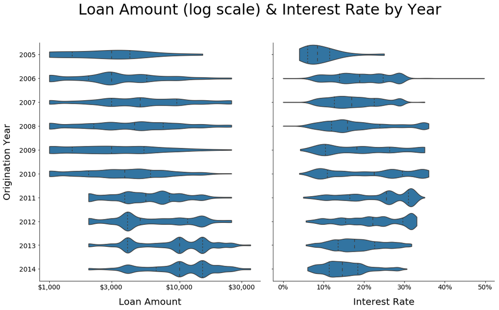

```python
# Create a PairGrid plotting LoanOriginalAmount & LogLoanOriginalAmount against categoric_vars.
x_labels = [0, 1000, 3000, 10000, 30000]

g = sns.PairGrid(data=df,  x_vars=['LogLoanOriginalAmount', 'BorrowerRate'], y_vars=['OriginationYear'],
                 height=9, aspect=0.8)

g.axes[-1,0].set_xticks(np.log10(x_labels))

g.map(sns.violinplot, inner='quartile', cut=0)

g.axes[-1,0].set_ylabel('Origination Year', fontdict={'fontsize':20}, labelpad=15)
g.axes[-1,0].set_xlabel('Loan Amount', fontdict={'fontsize':20}, labelpad=15)
g.axes[-1,1].set_xlabel('Interest Rate', fontdict={'fontsize':20}, labelpad=15)

g.axes[-1,0].set_xticklabels(['${:,.2f}'.format(x)[:-3] for x in x_labels])
g.axes[-1,1].set_xticklabels(['{:.0f}%'.format(x*100) for x in g.axes[-1,1].get_xticks()])

for ax in g.axes.flat:
    ax.tick_params(labelsize=14)

g.fig.suptitle('Loan Amount (log scale) & Interest Rate by Year', fontsize=32)
g.fig.subplots_adjust(top=0.85);
```

## Geographic Distribution

The next three slides have plots for population by state, loans by state, and a bar plot comparing the two. The first two are choropleth maps created using the Plotly graphing library. Comparing these two slides, you'll notice that they look nearly identical despite them being for different features. This is indicative of a very high degree of correlation. When calculated, the $\rho$ value for these two variables was 0.97.

By mousing over Iowa, Maine & North Dakota in the second slide, you'll see that the lender stopped originating loans after the economy collapsed in 2008, indicating that they either lost their license, or they didn't find it worth renewing after the recession. Looking at South Dakota, Nevada, Rhode Island, & DC, we see that the opposite is true. The lender didn't have any loans at all in these states during their first few years, but they began originating in them around 2008-2009.

```python
# Initialize pyplot in offline mode.
py.offline.init_notebook_mode(connected=True)

# Create scale for colorbar.
scl = [[0.0, 'rgb(218,218,235)'],[0.1, 'rgb(220,208,212)'],[0.2, 'rgb(223,198,189)'],[0.3, 'rgb(225,189,166)'],
       [0.4, 'rgb(227,179,143)'],[0.5, 'rgb(230,169,120)'],[0.6, 'rgb(232,159,97)'],[0.7, 'rgb(234,149,74)'],
       [0.8, 'rgb(236,140,51)'],[0.9, 'rgb(239,130,28)'],[1.0, 'rgb(241,120,5)']]

# Load data for choropleth map.
data = [dict(
    type='choropleth',
    autocolorscale=False,
    locations=df_map['State Code'],
    z=df_map['Population'],
    locationmode='USA-states',
    text=df_map['Population Text'],
    hoverinfo='location+text',
    colorscale=scl,
    reversescale=False,
    marker=dict(
        line=dict(
            color='rgb(255,255,255)',
            width=2
        )
    ),
    colorbar=dict(
        title='Residents',
        titlefont=dict(
            family='Arial'
        )
    )
)]

# Make layout for choropleth map.
layout = dict(
    autosize=False,
    width=780,
    height=500,
    images=[dict(
        source='https://i.imgur.com/SDhVixP.png',
        xref='paper', yref='paper',
        x=1.1, y=-0.35,
        sizex=0.5, sizey=0.5,
        xanchor='right', yanchor='bottom'
      )],
    title='Population by State 2014',
    titlefont=dict(
        family='Arial',
        size=28
    ),
    geo=dict(
        scope='usa',
        projection=dict(
            type='albers usa'
        ),
        showlakes=True,
        lakecolor='rgb(255,255,255)'
    )
)

# Create map figure.
fig = dict(data=data,
           layout=layout)

# Create config dict.
config = {'showLink':False,
          'displayModeBar':False}

# Plot map.
py.offline.iplot(fig, config=config);
```

[interactive chart not shown]

```python
# Initialize pyplot in offline mode.
py.offline.init_notebook_mode(connected=True)

# Create scale for colorbar.
scl = [[0.0, 'rgb(218,218,235)'],[0.1, 'rgb(220,208,212)'],[0.2, 'rgb(223,198,189)'],[0.3, 'rgb(225,189,166)'],
       [0.4, 'rgb(227,179,143)'],[0.5, 'rgb(230,169,120)'],[0.6, 'rgb(232,159,97)'],[0.7, 'rgb(234,149,74)'],
       [0.8, 'rgb(236,140,51)'],[0.9, 'rgb(239,130,28)'],[1.0, 'rgb(241,120,5)']]

# Load data for choropleth map.
data = [dict(
    type='choropleth',
    autocolorscale=False,
    locations=df_map['State Code'],
    z=df_map['Total'],
    locationmode='USA-states',
    text=df_map['Text'],
    hoverinfo='location+text',
    colorscale=scl,
    reversescale=False,
    marker=dict(
        line=dict(
            color='rgb(255,255,255)',
            width=2
        )
    ),
    colorbar=dict(
        title='Loans',
        titlefont=dict(
            family='Arial'
        )
    )
)]

# Make layout for choropleth map.
layout = dict(
    autosize=False,
    width=780,
    height=500,
    images=[dict(
        source='https://i.imgur.com/SDhVixP.png',
        xref='paper', yref='paper',
        x=1.1, y=-0.35,
        sizex=0.5, sizey=0.5,
        xanchor='right', yanchor='bottom'
      )],
    title='Loans by State 2006-2014',
    titlefont=dict(
        family='Arial',
        size=28
    ),
    geo=dict(
        scope='usa',
        projection=dict(
            type='albers usa'
        ),
        showlakes=True,
        lakecolor='rgb(255,255,255)'
    )
)

# Create map figure.
fig = dict(data=data,
           layout=layout)

# Create config dict.
config = {'showLink':False,
          'displayModeBar':False}

# Plot map.
py.offline.iplot(fig, config=config);
```

[interactive chart not shown]

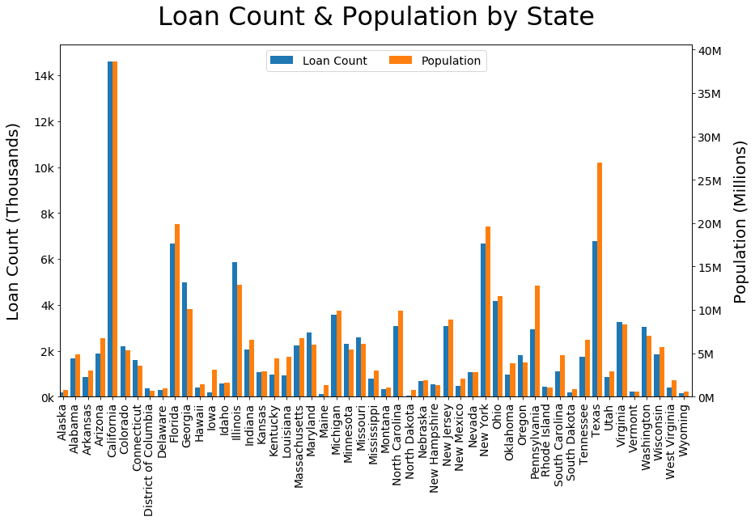

```python
# Create clustered bar chart with Loan Count & Population for each state.
fig = plt.figure(figsize=[14,8])

ax = fig.add_subplot(111)
ax2 = ax.twinx()

width = 0.4

df_map['Total'].plot(kind='bar', x='State', sharex=True, color=sns.color_palette()[0], ax=ax, width=width, position=1)
df_map['Population'].plot(kind='bar', x='State', color=sns.color_palette()[1], ax=ax2, width=width, position=0)

plt.title('Loan Count & Population by State', fontdict={'fontsize':32}, pad=25)

ax.set_xlabel('')
ax.set_ylabel('Loan Count (Thousands)', fontdict={'fontsize':20}, labelpad=15)
ax2.set_ylabel('Population (Millions)', fontdict={'fontsize':20}, labelpad=15)

ax.set_yticklabels(['{:,.0f}k'.format(x/1000) for x in ax.get_yticks()])
ax2.set_yticklabels(['{:,.0f}M'.format(x/1000000) for x in ax2.get_yticks()])
ax.tick_params(labelsize=14)
ax2.tick_params(labelsize=14)

lines, labels = ax.get_legend_handles_labels()
lines2, labels2 = ax2.get_legend_handles_labels()
ax2.legend(lines + lines2, ['Loan Count'] + ['Population'], loc=9, ncol=2, fontsize=14);
```